# Algorithm Class 12 - Practice 7

Binary Trees - I

June/9/2019

# 1 Tree and Graph

## 1.1 Tree Nodes and Graph Nodes

```
    8
  /   \
2       98
 \     /  \
 18   1   100
```

```java
class TreeNode {
  int key;  // any types of data, this case is a int
  TreeNode left;
  TreeNode right;
  // TreeNode parent;
  // We can store parent reference as well, this will be useful for solving some problems.
  public TreeNode(int key) {
    this.key = key;
  }
}
```

**Linked List** is a special kind of Tree (if there is only one child for each of the node in the binary tree, it can be reduced to a linked list).

Usually, we use the root to represent the binary tree.

General Tree, each node can have arbitrary number of children.

```
        5
    /  / |  \
   3  1  8  10
 / |  |     |  \  \
2  4  12    6  20  9
```

```java
class TreeNode {
  int key;
  List<TreeNode> children;  // do not add null to children
  // TreeNode parent;
  public TreeNode(int key) {
    this.key = key;
    children = new ArrayList<TreeNode>();
  }
}
```

Tree is a special kind of **Graph**:

```java
class GraphNode {
  int key;
  List<GraphNode> neighbors;
  public GraphNode(int key) {
    this.key = key;
    neightbors = new ArrayList<GraphNode>();
  }
}
```

Tree is a DAG.

- DAG (有向無環圖): Directed Acyclic Graph

## 1.2 Characteristics of Graph

1. Graph is not necessarily connected.
   1. `List<GraphNode> graph`
2. When you analyze time & space complexity of a graph, use two parameters: V (vertex) & E (edge).
   1. Given V, the largest E is O($\text{V}^2$).
   2. Given V, the smallest E is 0.

## 1.3 Difference Between Tree and Graph

1. To give you a graph, they need to give you the `List<Graphnode>` list, but not only a single node.
2. When you analyze time & space complexity, use both V and E.
   - Given V, the maximum value for E is O($\text{V}^2$).
   - Given V, the minimum value for E is 0.

## 1.4 Representation of Graph

### 1.4.1 Graph Nodes

As introduced above:

```java
class GraphNode {
  int key;
  List<GraphNode> neighbors;
  public GraphNode(int key) {
    this.key = key;
    neightbors = new ArrayList<GraphNode>();
  }
}
```

### 1.4.2 Adjacency List

Vertices are stored as records or objects, and every vertex stores a list of adjacent vertices. This data structure allows the storage of additional data on the vertices. Additional data can be stored if edges are also stored as objects, in which case each vertex stores its incident edges and each edge stores its incident vertices.

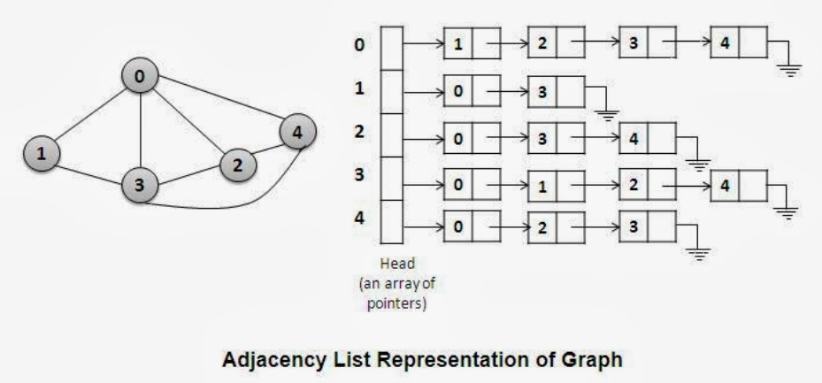

When coding, you can use integers to represent vertex. In this way, a graph can be represented as:

```
List<List<Integer>>

graph.get(1) -> Node 1's neighbors
graph.get(2) -> Node 2's neighbors
...
graph.get(i) -> Node i's neighbors

for (Integer i : graph.get(1)) {
  // i is a neighbor of node 1
}
```

### 1.4.3 Adjacency Matrix

```
   | 0 | 1 | 2 | 3
---|---|---|---|---
 0 |   | T |   |
 1 |   |   | T |
 2 |   |   |   |
 3 |   |   |   |
```

# 2 Traversals of Binary Tree

1. Pre-order: root, left sub, right sub
2. In-order: left sub, root, right sub
3. Post-order: left sub, right sub, root

Like linked list, general ways of solving problems about binary (search) tree:

**1. Recursive:**

Divide and conquer is nature of binary tree: binary tree can be easily divided into three parts

- solve problem for left/right subtree
- solve the problem for root

**2. Iterative:**

- could be complicated for binary tree but we need to know how.

Level order traversal: Try to build one for your LaiCode test cases.

# 3 Binary Search Tree (BST)

Binary Search Tree is a binary tree maintains the following property: for any of the nodes in the binary tree, all the nodes in its right subtree is larger than itself, all the nodes in its left subtree is smaller than itself (compared by the key stored in each of the nodes).

```
   10
 /    \
5      15
 \    /  \
  8  14  16
 / \
6   9
```

## 3.1 Basic Operations of Binary Search Tree

1. `search()`: worst case O($n$), average O($\log(n)$)
2. `insert()`: worst case O($n$), average O($\log(n)$)
3. `remove()`: worst case O($n$), average O($\log(n)$)

## 3.2 Balanced Binary Search Tree

`search()`, `insert()`, `remove()` operations are all guaranteed to be O($\log(n)$).

E.g. AVL Tree, Red-Black Tree, etc.

Red-Black Tree:

- in Java: TreeMap/TreeSet
- in C++: map/set

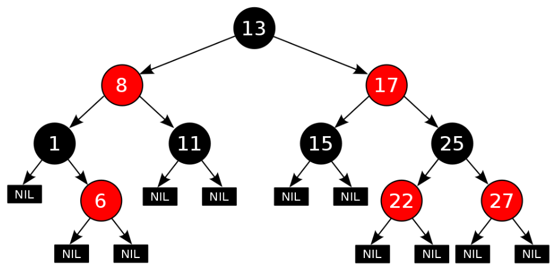

Properties of Red-Black Tree:

1. Each node is either red or black.
2. The root is black.
3. All NIL (null) are black.
4. If a node is red, then both its children are black.
5. Every path from a given node to any of its descendant NIL nodes contains the same number of black nodes.

We are not going to implement balanced binary search tree, instead we are more interested in basic implementation.

## 3.3 Search in BST

```
   10
 /    \
5      15
 \    /  \
  8  14  16
 / \
6   9
```

```java
class TreeNode {
  int key;
  TreeNode left;
  TreeNode right;
  public TreeNode(int key) {
    this.key = key;
  }
}
```

**1. Recursive `search(root, target)`**

- sub-problem: `search(root.left, target)`, `search(root.right, target)`
- recursion rule:
  - if target < root, return `search(root.left, target)`
  - if target > root, return `search(root.right, target)`
- base case

```java
public TreeNode search(TreeNode root, int target) {
  if (root == null || root.key == target) {
    return root;
  }
  if (target < root.key) {
    return search(root.left, target);
  }
  else {
    return search(root.right, target);
  }
}
```

- Time: O($\text{height}$); worse case O($n$), average O($\log(n)$)
- Space: O($\text{height}$)
  - Heap: 0
  - Stack: O($1$) for each level

**2. Iterative `search(root, target)`**

```java
public TreeNode search(TreeNode root, int target) {
  TreeNode curr = root;
  while (curr != null && curr.key != target) {  // terminate condition
    if (target < curr.key) {
      curr = curr.left;
    }
    else {
      curr = curr.right;
    }
  }
  // exit while loop: curr == null || curr.key == target
  return curr;
}
```

## 3.4 Tail Recursion

The recursive call is always the last execution statement.

We can easily transfer the tail recursive to iterative solution.

```
               root
      /      |                          \
terminate  return                     return
condition  search(root.left, target)  search(root.right, target)
```

Not a tail recursion:

```
...
return isBst(root.left, ...) && isBst(root.right, ...);
```

**The iterative solution of the recursive method:**

```java
public TreeNode search(TreeNode root, int target) {
  while (root != null) {
    if (root.value == target) {
      return root;
    }
    else if (root.value < target) {
      root = root.right;
    }
    else {
      root = root.left;
    }
  }
  return null;
}
```

If using Google Doc:

1. Use Courier New
2. Auto capitalization - turn off
3. Use TAB, don’t use space

## 3.5 Insert in a Binary Search Tree

```
   10        target == 7
 /    \
5      15
 \    /  \
  8  14  16
 / \
6   9

---

   10
 /    \
5      15
 \    /  \
  8  14  16
 / \
6   9
 \
  7
```

```
   10        target == 3
 /    \
5      15
 \    /  \
  8  14  16
 / \
6   9

---

     10
   /    \
  5      15
 / \    /  \
3   8  14  16
   / \
  6   9
```

```
   10        target == 17
 /    \
5      15
 \    /  \
  8  14  16
 / \
6   9

---

   10
 /    \
5      15
 \    /  \
  8  14  16
 / \       \
6   9      17
```

Property: the target will always be inserted as a leaf.

```
   10
 /    \
5      15
 \    /  \
  8  14  16
 / \
6   9

Bottom: null 5 null 6 null 8 null 9 null 10 null 14 null 15 null 16 null
```

**1. Iterative (I) `insert(root, target)`**

```java
public TreeNode insert(TreeNode root, int target) {
  TreeNode newNode = new TreeNode(target);
  if (root == null) {
    return newNode;
  }
  TreeNode curr = root;
  while (curr.key != target) {
    if (curr.key > target) {
      if (curr.left != null) {
        curr = curr.left;
      }
      else {
        curr.left = newNode;
        break;
      }
    }
    else {
      if (curr.right != null) {
        curr = curr.right;
      }
      else {
        curr.right = newNode;
        break;
      }
    }
  }
  return root;
}
```

**2. Iterative (II) `insert(root, target)`**

```java
public TreeNode insert(TreeNode root, int target) {
  TreeNode newNode = new TreeNode(target);
  if (root == null) {
    return newNode;
  }
  TreeNode returnRoot = root;
  TreeNode prev = null;
  while (root != null) {
    prev = root;
    if (root.key < target) {
      root = root.right;
    }
    else if (root.key > target) {
      root = root.left;
    }
    else {
      return returnRoot;
    }
  }
  if (prev.key < target) {
    prev.right = newNode;
  }
  else if (prev.key > target) {
    prev.left = newNode;
  }
  return returnRoot;
}
```

**3. Recursion (I) `insert(root, target)`**

A very common way when the tree structure could be changed, in this case, we return the **new root** after the change. (Remind about the same case of Linked List?)

Recursive analysis:

- sub-problem: `insert(root.left, target)`, `insert(root.right, target)`
- recursion rule:
  - if target < root.value, root.left = `insert(root.left, target)`
  - if target > root.value, root.right = `insert(root.right, target)`
- base case
  - root == null, return new TreeNode(target)
  - root.value == target, return root

```java
public TreeNode insert(TreeNode root, int target) {
  if (root == null) {
    TreeNode newRoot = new TreeNode(target);
    return newRoot;
  }
  if (root.key < target) {
    root.right = insert(root.right, target);
  }
  else if (root.key > target) {
    root.left = insert(root.left, target);  // break point
  }
  return root;
}
```

```
            root
        /          \ (root.key < target)
terminate          root.right = insert(root.right, target);
                   return root;
```

**4. Recursion (II) `insert(root, target)`**

Remove redundant operation

```java
public static TreeNode insert(TreeNode root, int target) {
  if (root == null) {
    return new TreeNode(target);
  }
  helper(root, target);
  return root;
}

public static void helper(TreeNode root, int target) {
  if (target == root.key) {
    return;
  }
  else if (target < root.key) {
    if (root.left == null) {
      root.left = new TreeNode(target);
    }
    else {
      helper(root.left, target);
    }
  }
  else {
    if (root.right == null) {
      root.right = new TreeNode(target);
    }
    else {
      helper(root.right, target);
    }
  }
}
```